# Homework 1 - Truth Tables & Linear Programming with AMPL

Daniel Carpenter

January 2022

# 1 Problem `1`

# 2 Problem `2`

# 3 Problem `3`

## 3.1 Task `a`

### 3.1.1 Decision Variables

`bondA`: dollars $\in \mathbb{R}$ to invest in bond A  
`bondB`: dollars $\in \mathbb{R}$ to invest in bond B  
`bondC`: dollars $\in \mathbb{R}$ to invest in bond C  
`bondD`: dollars $\in \mathbb{R}$ to invest in bond D  
`bondE`: dollars $\in \mathbb{R}$ to invest in bond E

### 3.1.2 Objective Function

- Maximize the Expected Earnings of the portfolio

$$Maximize \ Z = (0.043 \times bondA) + (0.027 \times bondB) + (0.025 \times bondC) + (0.022 \times bondD) + (0.045 \times bondE)$$

### 3.1.3 Constraints

**C1:** Budget to invest is $10 MM or less
$$budget: bondA + bondB + bondC + bondD + bondE \leq 10$$

**C2:** At least $4 million must be invested in government and agency bonds
$$govtAndAgency: bondB + bondC + bondD \geq 4$$

**C3:** Average Quality of the Portfolio must not exceed 1.4
$$avgQuality: (0.6 \times bondA) + (0.6 \times bondB) - (0.4 \times bondC)
- (0.4 \times bondD) + (3.6 \times bondE) \leq 0$$

**C4:** The Average Maturity must not Exceed Five Years
$$avgMaturity: (4 \times bondA) + (10 \times bondB) - (1 \times bondC)
- (2 \times bondD) - (3 \times bondE) \leq 0$$

### 3.1.4 Code

[figure not shown]

### 3.1.5 Output

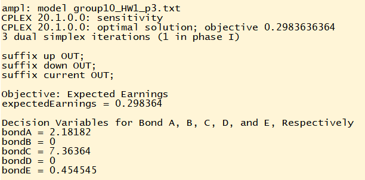

# 4 Problem `4`

## 4.1 Task `a`

### 4.1.1 Decision Variables

`tv` = the number of minutes $\in \mathbb{R}$ to air advertising on the *television* medium  
`magazine` = the number of pages $\in \mathbb{I}$ to to advertise on the *magazine* medium

### 4.1.2 Objective Function

- Maximize the total audience reach

$$Maximize \ Z = (1.8\times tv) + (1.0 \times magazine)$$

### 4.1.3 Constraints

**C1**: Must not Exceed Budget of 1 Million dollars
$$budget: (20,000 \times tv) + (10,000 \times magazine) \leq 1,000,000$$

**C2**: Must have at least 10 minutes of air time on the TV medium
$$minTimeTV: tv \geq 10$$

### 4.1.4 Code

[figure not shown]

### 4.1.5 Output

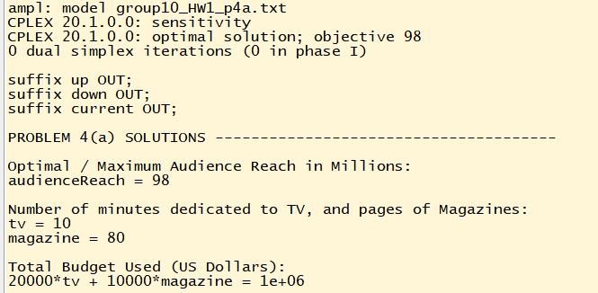

### 4.1.6 Solving Problem `4(a)` Graphically by Hand

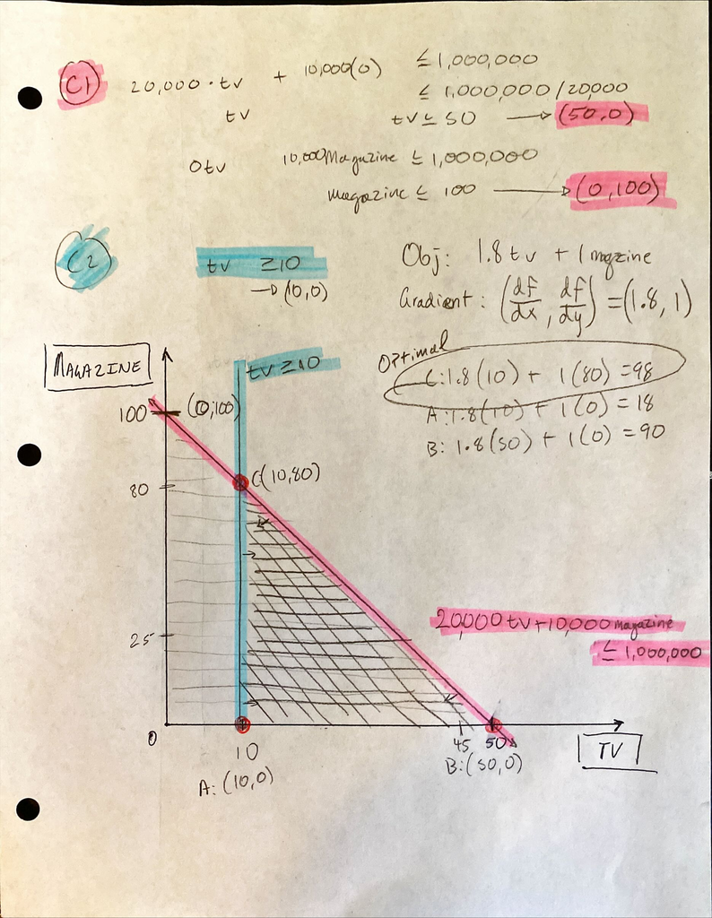

## 4.2 Task `b`

### 4.2.1 Additional Constraint: Labor Time

**C3**: Only 100 person weeks available, given it takes three weeks and one week to create a `tv` and `magazine` minute for advertisement, respectively.
$$personWeeks: (3 \times tv) + (1 \times magazine) \leq 100$$

### 4.2.2 Code

[figure not shown]

### 4.2.3 Output

[figure not shown]

## 4.3 Task `c`

### 4.3.1 Additional Constraint: Radio Advertising Medium

### 4.3.2 Decision Variables

`tv` = the number of minutes $\in \mathbb{R}$ to air advertising on the *television* medium  
`magazine` = the number of pages $\in \mathbb{I}$ to to advertise on the *magazine* medium `radio` = the number of minutes $\in \mathbb{R}$ to air advertising on the *radio* medium

### 4.3.3 Objective Function

- Maximize the total audience reach

$$Maximize \ Z = (1.80\times tv) + (1.00 \times magazine) + (0.25 \times radio)$$

### 4.3.4 New Constraints

**C1**: Must not Exceed Budget of 1 Million dollars
$$budget: (20,000 \times tv) + (10,000 \times magazine) + (2,000 \times radio) \leq 1,000,000$$

**C2**: Must have at least 10 minutes of air time on the TV medium
$$minTimeTV: tv \geq 10$$

**C3**: Only 100 person weeks available, given it takes three weeks and one week to create a `tv` and `magazine` minute for advertisement, respectively. It only takes one day for `radio`.
$$personWeeks: (3 \times tv) + (1 \times magazine) + (\frac{1}{7} \times radio) \leq 100$$

### 4.3.5 Code

[figure not shown]

### 4.3.6 Output

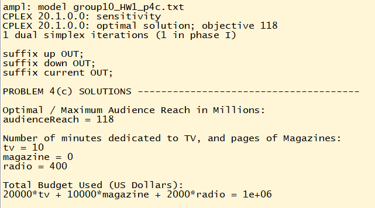

## 4.4 Task `d`

### 4.4.1 Additional Constraints: Miminum Magazine and Maximum Radio Requirements

**C4**: Must sign up for at least 2 magazine pages
$$minMagazines: magazine \geq 2$$

**C5**: Must to exceed 120 minutes of radio
$$maxRadio: radio \leq 120$$

### 4.4.2 Code

[figure not shown]

### 4.4.3 Output

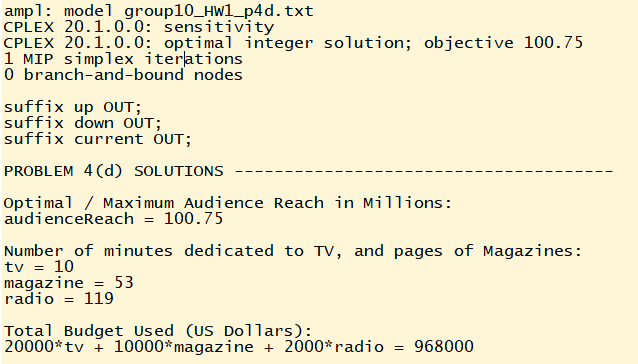

# 5 Problem `5`

## 5.1 Base Mathematical Formulation and Code

- *Each task shows a separate change to the base model. Therefore, each change should not accumulate.*

### 5.1.1 Mathematical Formulation

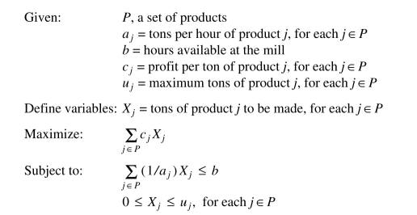

### 5.1.2 Code for Model `.mod` and Input Data `.dat`

[figure not shown]

## 5.2 Task `a`

### 5.2.1 Changed Constraint for Total Hours

- *Change the constraints so that total hours used by all products must equal the total hours available for each stage*

### 5.2.2 Code

[figure not shown]

### 5.2.3 Output

> There is no difference in the optimal solution because the range of Time before there is a change in optimal remains the same, and the hours available have not changed.

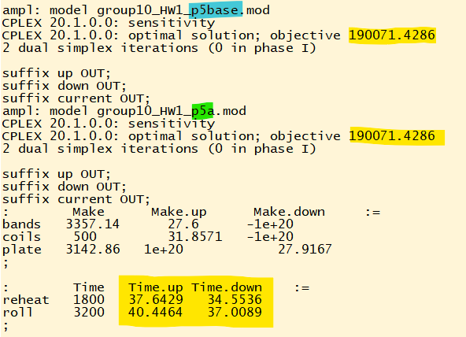

## 5.3 Task `b`

### 5.3.1 New Constraint for Max Weight

- *Restrict the total weight of all products to be less than a new parameter, max_weight = 6,500*

$$totalWeight: \sum_{p \ \in \ PROD} Make_{p} \leq max\_weight$$

### 5.3.2 Code

[figure not shown]

### 5.3.3 Output

> The total number of tons has reduced from 7,000 to 6,500 per week

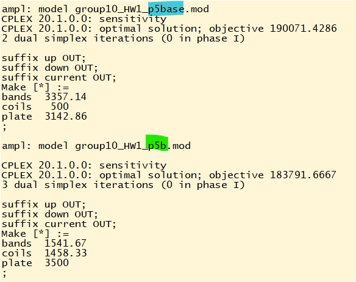

## 5.4 Task `c`

### 5.4.1 Changed Objective Function

- *Change the objective function to maximize total tons*

## 5.6 Task `e`

# 6 Problem `6`

## 6.1 Task `a` - `c`

### 6.1.1 Decision Variables

`bondA`: dollars $\in \mathbb{R}$ to invest in bond A  
`bondB`: dollars $\in \mathbb{R}$ to invest in bond B  
`bondC`: dollars $\in \mathbb{R}$ to invest in bond C  
`bondD`: dollars $\in \mathbb{R}$ to invest in bond D  
`bondE`: dollars $\in \mathbb{R}$ to invest in bond E

### 6.1.2 Objective Function

- Maximize the Expected Earnings of the portfolio

$$Maximize \ Z = (0.043 \times bondA) + (0.027 \times bondB) + (0.025 \times bondC) + (0.022 \times bondD) + (0.045 \times bondE)$$

### 6.1.3 Constraints

**C1:** Budget to invest is $10 MM or less
$$budget: bondA + bondB + bondC + bondD + bondE \leq 10$$

**C2:** At least $4 million must be invested in government and agency bonds
$$govtAndAgency: bondB + bondC + bondD \geq 4$$

**C3:** Average Quality of the Portfolio must not exceed 1.4
$$avgQuality: (0.6 \times bondA) + (0.6 \times bondB) - (0.4 \times bondC)
- (0.4 \times bondD) + (3.6 \times bondE) \leq 0$$

**C4:** The Average Maturity must not Exceed Five Years
$$avgMaturity: (4 \times bondA) + (10 \times bondB) - (1 \times bondC)
- (2 \times bondD) - (3 \times bondE) \leq 0$$

**C5:** Only select Bonds A and D (Don’t select B, C, or E)
$$onlyAandB: bondB + bondC + bondE = 0;$$

**C6:** Municipal Bonds must be less than or equal to $3 MM
$$municipal: bondA \leq 3;$$

### 6.1.4 Code

[figure not shown]

### 6.1.5 Output

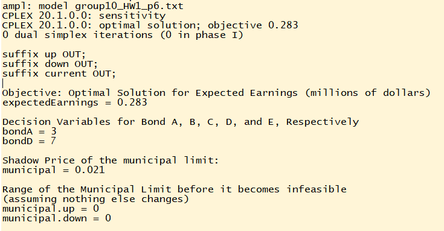

## 6.2 Task `d`:

You may not borrow more than 2.83%, since that is the expected  
yield to maturity (30% of bondA * 4.3%) + (70% of bondD * 2.2%)

## 6.3 Task `e`:

If you borrowed at a rate greater than the expected YTM, then the  
venture would not be profitable.